# Data_Mining_OLAP

### Tiền xử lý dữ liệu (Data Preparation)

1. KHỞI TẠO VÀ IMPORT THƯ VIỆN

Import các thư viện cần thiết

```python
import pandas as pd
import numpy as np
import statsmodels.api as sm
import matplotlib.pyplot as plt
import seaborn as sns
from statsmodels.tsa.seasonal import seasonal_decompose

# Import các thư viện Machine Learning
from sklearn.ensemble import VotingRegressor, RandomForestRegressor
from sklearn.linear_model import LinearRegression
from xgboost import XGBRegressor, plot_importance
from sklearn.model_selection import TimeSeriesSplit, GridSearchCV
from sklearn.metrics import mean_squared_error, mean_absolute_percentage_error, r2_score

# Tắt cảnh báo không cần thiết
import warnings
warnings.filterwarnings("ignore")
```

Tải lên file .csv chứa dữ liệu bán hàng

```python
from google.colab import files
uploaded = files.upload()
```

Upload widget is only available when the cell has been executed in the current browser session. Please rerun this cell to enable.

```
Saving Hydraulic_Sales_DW.csv to Hydraulic_Sales_DW.csv
```

Đọc file .csv vừa tải lên

```python
data = pd.read_csv('Hydraulic_Sales_DW.csv')
data.head()
```

|  | date | month | quarter | year | country | region | product_type | product_code | variant | new_product_launch | ... | revenue | marketing_spend | discount_percent | stock_available | lead_time_days | competitor_activity | seasonality_index | economic_indicator | failure_rate_pct | return_units |
| --- | --- | --- | --- | --- | --- | --- | --- | --- | --- | --- | --- | --- | --- | --- | --- | --- | --- | --- | --- | --- | --- |
| 0 | 00:00.0 | 7 | 3 | 2022 | USA | South | DC Valve | DCV-315 | 3-position | 0 | ... | 1248000 | 14970 | 4 | 184 | 18 | 5 | 0.94 | 7.52 | 2.42 | 1 |
| 1 | 00:00.0 | 5 | 2 | 2021 | USA | North | DC Valve | DCV-315 | 4-position | 0 | ... | 1560000 | 19474 | 7 | 286 | 18 | 6 | 1.02 | 6.30 | 2.23 | 3 |
| 2 | 00:00.0 | 10 | 4 | 2020 | Brazil | South | DC Valve | DCV-315 | 3-position | 0 | ... | 1380000 | 27734 | 9 | 105 | 14 | 7 | 1.14 | 7.48 | 2.24 | 3 |
| 3 | 00:00.0 | 1 | 1 | 2024 | USA | South | DC Valve | DCV-315 | 4-position | 0 | ... | 1326000 | 15710 | 7 | 121 | 6 | 5 | 0.94 | 6.36 | 0.82 | 3 |
| 4 | 00:00.0 | 5 | 2 | 2020 | Germany | East | DC Valve | DCV-315 | 2-position | 0 | ... | 1776000 | 44006 | 13 | 302 | 10 | 5 | 0.90 | 8.08 | 0.65 | 2 |

5 rows × 28 columns

2. KIỂM TRA DỮ LIỆU

Kiểm tra cấu trúc dữ liệu

```python
data.info()
```

```
<class 'pandas.core.frame.DataFrame'>
RangeIndex: 228045 entries, 0 to 228044
Data columns (total 28 columns):
 #   Column                Non-Null Count   Dtype
---  ------                --------------   -----
 0   date                  228045 non-null  object
 1   month                 228045 non-null  int64
 2   quarter               228045 non-null  int64
 3   year                  228045 non-null  int64
 4   country               228045 non-null  object
 5   region                228045 non-null  object
 6   product_type          228045 non-null  object
 7   product_code          228045 non-null  object
 8   variant               228045 non-null  object
 9   new_product_launch    228045 non-null  int64
```

[output cut: 20 more lines]

Kiểm tra số lượng dòng bị trùng và số lượng dữ liệu thiếu.

```python
data.isna().sum()
```

|  | 0 |
| --- | --- |
| date | 0 |
| month | 0 |
| quarter | 0 |
| year | 0 |
| country | 0 |
| region | 0 |
| product_type | 0 |
| product_code | 0 |
| variant | 0 |
| new_product_launch | 0 |
| oil_type | 0 |
| pressure_rating_bar | 0 |
| temperature_rating_c | 0 |
| unit_price | 0 |
| channel_name | 0 |
| CustomerSegment_name | 0 |
| ApplicationArea_name | 0 |
| units_sold | 0 |
| revenue | 0 |
| marketing_spend | 0 |
| discount_percent | 0 |
| stock_available | 0 |
| lead_time_days | 0 |
| competitor_activity | 0 |
| seasonality_index | 0 |
| economic_indicator | 0 |
| failure_rate_pct | 0 |
| return_units | 0 |

**dtype:** int64

```python
data.duplicated().sum()
```

```
np.int64(0)
```

3. XỬ LÝ DỮ LIỆU & GOM NHÓM

```python
# Chuẩn hóa tên cột
data.columns = [col.lower().strip() for col in data.columns]

# Xử lý ngày tháng an toàn
if 'year' in data.columns and 'month' in data.columns:
    data['day'] = 1
    data['year'] = pd.to_numeric(data['year'], errors='coerce')
    data['month'] = pd.to_numeric(data['month'], errors='coerce')
    data['date'] = pd.to_datetime(data[['year', 'month', 'day']], errors='coerce')
elif 'date' in data.columns:
    data['date'] = pd.to_datetime(data['date'], errors='coerce')

# Xóa dòng lỗi ngày tháng
data = data.dropna(subset=['date'])

# Gom nhóm theo tháng (Aggregation)
df_agg = data.groupby('date').agg({
    'units_sold': 'sum',
    'stock_available': 'sum',
    'discount_percent': 'mean',
    'economic_indicator': 'mean',
    'competitor_activity': 'mean',
    'lead_time_days': 'mean'
}).asfreq('MS').fillna(0)

print(f"\n✅ Dữ liệu sau khi cộng gộp ({len(df_agg)} tháng):")
print(df_agg.head())
```

```
✅ Dữ liệu sau khi cộng gộp (60 tháng):
            units_sold  stock_available  discount_percent  economic_indicator  \
date
2020-01-01      664669          1132010          8.442222            6.996315
2020-02-01      664992          1146812          8.588544            6.996206
2020-03-01      661783          1139036          8.471579            7.009213
2020-04-01      658488          1123438          8.489635            7.012488
2020-05-01      660882          1153447          8.537431            7.003381

            competitor_activity  lead_time_days
date
2020-01-01             4.455646       12.053435
2020-02-01             4.487388       11.938255
2020-03-01             4.446316       12.037105
2020-04-01             4.439255       11.979533
2020-05-01             4.494615       12.123719
```

### Khám phá dữ liệu (EDA - Exploratory Data Analysis)

Thống kê dữ liệu

```python
data.describe()
```

|  | date | month | quarter | year | new_product_launch | pressure_rating_bar | temperature_rating_c | unit_price | units_sold | revenue | marketing_spend | discount_percent | stock_available | lead_time_days | competitor_activity | seasonality_index | economic_indicator | failure_rate_pct | return_units | day |
| --- | --- | --- | --- | --- | --- | --- | --- | --- | --- | --- | --- | --- | --- | --- | --- | --- | --- | --- | --- | --- |
| count | 228045 | 228045.000000 | 228045.000000 | 228045.000000 | 228045.000000 | 228045.000000 | 228045.000000 | 228045.000000 | 228045.000000 | 2.280450e+05 | 228045.000000 | 228045.000000 | 228045.000000 | 228045.000000 | 228045.000000 | 228045.000000 | 228045.000000 | 228045.000000 | 228045.000000 | 228045.0 |
| mean | 2022-06-16 16:13:33.060580352 | 6.498669 | 2.499590 | 2022.000228 | 0.100542 | 255.122169 | 95.018527 | 5957.227740 | 174.550878 | 1.039705e+06 | 32638.893012 | 8.502598 | 299.343581 | 12.001829 | 4.504076 | 1.049908 | 7.000116 | 1.298290 | 1.998588 | 1.0 |
| min | 2020-01-01 00:00:00 | 1.000000 | 1.000000 | 2020.000000 | 0.000000 | 160.000000 | 80.000000 | 5000.000000 | 50.000000 | 2.500000e+05 | 10000.000000 | 3.000000 | 100.000000 | 5.000000 | 0.000000 | 0.850000 | 5.500000 | 0.100000 | 0.000000 | 1.0 |
| 25% | 2021-03-01 00:00:00 | 3.000000 | 1.000000 | 2021.000000 | 0.000000 | 200.000000 | 90.000000 | 6000.000000 | 112.000000 | 6.660000e+05 | 20054.000000 | 5.000000 | 199.000000 | 8.000000 | 2.000000 | 0.950000 | 6.250000 | 0.700000 | 1.000000 | 1.0 |
| 50% | 2022-07-01 00:00:00 | 6.000000 | 2.000000 | 2022.000000 | 0.000000 | 250.000000 | 100.000000 | 6000.000000 | 174.000000 | 1.038000e+06 | 30205.000000 | 8.000000 | 300.000000 | 12.000000 | 5.000000 | 1.050000 | 7.000000 | 1.300000 | 2.000000 | 1.0 |
| 75% | 2023-10-01 00:00:00 | 9.000000 | 3.000000 | 2023.000000 | 0.000000 | 315.000000 | 110.000000 | 6000.000000 | 237.000000 | 1.410000e+06 | 40266.000000 | 12.000000 | 399.000000 | 16.000000 | 7.000000 | 1.150000 | 7.750000 | 1.900000 | 3.000000 | 1.0 |
| max | 2024-12-01 00:00:00 | 12.000000 | 4.000000 | 2024.000000 | 1.000000 | 350.000000 | 110.000000 | 6000.000000 | 299.000000 | 1.794000e+06 | 499750.000000 | 14.000000 | 499.000000 | 19.000000 | 9.000000 | 1.250000 | 8.500000 | 2.500000 | 4.000000 | 1.0 |
| std | NaN | 3.452168 | 1.118148 | 1.414288 | 0.300721 | 70.319502 | 11.173934 | 202.343701 | 72.070013 | 4.309072e+05 | 31283.612199 | 3.459157 | 115.383161 | 4.318727 | 2.869655 | 0.115472 | 0.865431 | 0.693459 | 1.415335 | 0.0 |

```python
data.describe(include = 'object')
```

|  | country | region | product_type | product_code | variant | oil_type | channel_name | customersegment_name | applicationarea_name |
| --- | --- | --- | --- | --- | --- | --- | --- | --- | --- |
| count | 228045 | 228045 | 228045 | 228045 | 228045 | 228045 | 228045 | 228045 | 228045 |
| unique | 4 | 4 | 2 | 4 | 6 | 4 | 4 | 4 | 4 |
| top | Brazil | South | DC Valve | DCV-315 | 4-position | HVLP46 | Offline | OEM | Agriculture |
| freq | 57037 | 57046 | 218182 | 195058 | 73560 | 57161 | 57422 | 57032 | 57192 |

1. Xu hướng dài hạn của doanh số trong 4 năm qua biến động như thế nào và Chu kỳ kinh doanh của công ty lặp lại như thế nào trong một năm? Đâu là các tháng cao điểm và thấp điểm? Sau khi tách bỏ xu hướng và mùa vụ, phần nhiễu còn lại có lớn không?
- Mục tiêu: Giải mã **cấu trúc nội tại** của dữ liệu doanh số thông qua kỹ thuật Phân rã chuỗi thời gian (**Time Series Decomposition**) để đạt được 3 mục đích: Đánh giá chiến lược (**Trend**), Tối ưu vận hành theo mùa vụ (**Seasonality**), Kiểm tra độ tin cậy của dữ liệu/đo lường mức độ nhiễu (**Residuals**)

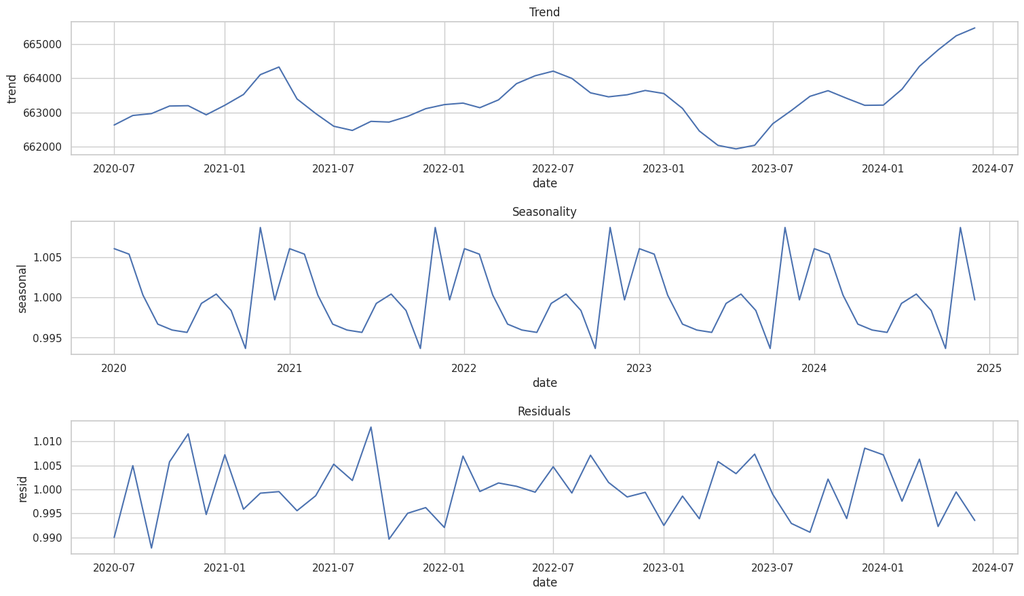

```python
#perform seasonal decomposition
result = seasonal_decompose(df_agg['units_sold'], model='multiplicative', period=12)

#plot the components in the graph
sns.set(style='whitegrid')
plt.figure(figsize=(18,14))

#trend component
plt.subplot(411)
sns.lineplot(data=result.trend)
plt.title('Trend')
plt.xticks(rotation=0)
plt.subplots_adjust(hspace=2)

#seasonal component
plt.subplot(412)
sns.lineplot(data=result.seasonal)
plt.title('Seasonality')
plt.subplots_adjust(hspace=2)

#residuals component
plt.subplot(413)
sns.lineplot(data=result.resid)
plt.title('Residuals')
plt.subplots_adjust(hspace=0.5)
```

2. Trong bối cảnh Kinh tế suy thoái (**economic_indicator thấp**), nếu Đối thủ tấn công mạnh (**competitor_activity cao**), doanh số của chúng ta có bị sụt giảm nghiêm trọng hơn so với khi kinh tế tốt không?
- Mục tiêu: Đánh giá độ "tổn thương" của doanh nghiệp trước các tác động kép (Double Trouble). Từ đó kết luận xem yếu tố nào (Kinh tế hay Đối thủ) ảnh hưởng đến doanh số lớn hơn.

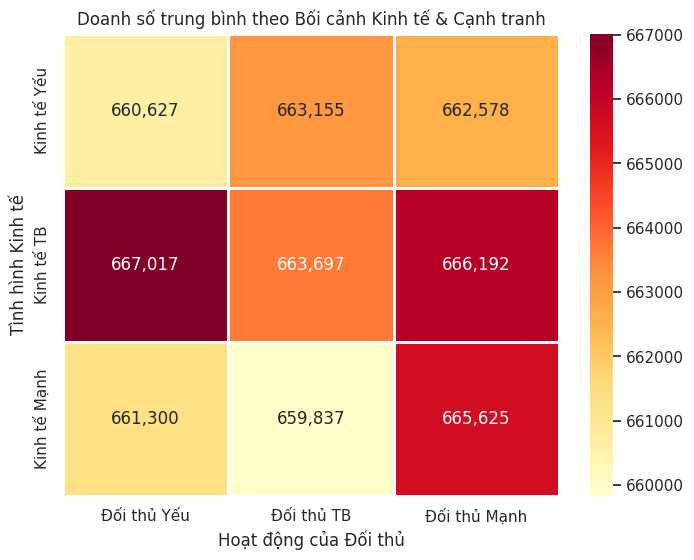

```python
# 1. Chia nhóm cho Kinh tế và Đối thủ
df_agg['Eco_Bin'] = pd.qcut(df_agg['economic_indicator'], q=3, labels=['Kinh tế Yếu', 'Kinh tế TB', 'Kinh tế Mạnh'])
df_agg['Comp_Bin'] = pd.qcut(df_agg['competitor_activity'], q=3, labels=['Đối thủ Yếu', 'Đối thủ TB', 'Đối thủ Mạnh'])

# 2. Tính doanh số trung bình cho từng cặp
pivot_table = df_agg.pivot_table(index='Eco_Bin', columns='Comp_Bin', values='units_sold', aggfunc='mean')

# 3. Vẽ Heatmap
plt.figure(figsize=(8, 6))
sns.heatmap(pivot_table, annot=True, fmt=',.0f', cmap='YlOrRd', linewidths=1)
plt.title('Doanh số trung bình theo Bối cảnh Kinh tế & Cạnh tranh')
plt.xlabel('Hoạt động của Đối thủ')
plt.ylabel('Tình hình Kinh tế')
plt.show()
```

Dựa trên phân tích biên độ biến thiên của doanh số trong ma trận rủi ro, cho thấy cả hai yếu tố đều có tác động ở mức độ tương đương nhau, nhưng Kinh tế vẫn là yếu tố nền tảng quan trọng hơn.

Điều này gợi ý rằng chiến lược kinh doanh của công ty cần ưu tiên khả năng thích ứng với các chu kỳ kinh tế vĩ mô (Macro-economic cycles) hơn là chỉ tập trung đối phó với các động thái ngắn hạn của đối thủ.

3. Khi kinh tế khó khăn (chỉ số thấp), khách hàng có trở nên nhạy cảm hơn với giá không? Liệu giảm giá (discount_percent) có hiệu quả hơn trong thời kỳ kinh tế yếu?
- Mục tiêu: Phân tích tác động tương tác (Interaction Effect) giữa bối cảnh kinh tế vĩ mô và chiến lược giá lên doanh số bán hàng.

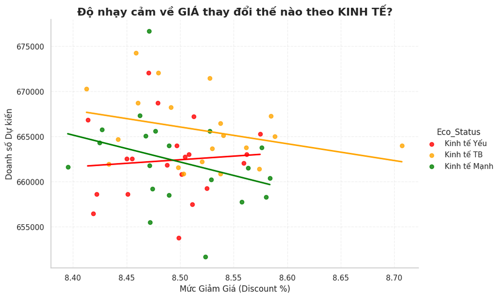

```python
df_agg['Eco_Status'] = pd.qcut(df_agg['economic_indicator'], q=3, labels=['Kinh tế Yếu', 'Kinh tế TB', 'Kinh tế Mạnh'])
plt.figure(figsize=(10, 6))

# Vẽ đường hồi quy cho từng nhóm Kinh tế để xem độ dốc (Độ nhạy)
sns.lmplot(
    data=df_agg,
    x='discount_percent',
    y='units_sold',
    hue='Eco_Status',  # Màu sắc theo tình hình kinh tế
    palette={'Kinh tế Yếu': 'red', 'Kinh tế TB': 'orange', 'Kinh tế Mạnh': 'green'},
    height=6,
    aspect=1.5,
    ci=None # Tắt khoảng tin cậy cho dễ nhìn
)

plt.title('Độ nhạy cảm về GIÁ thay đổi thế nào theo KINH TẾ?', fontsize=16, fontweight='bold')
plt.xlabel('Mức Giảm Giá (Discount %)')
plt.ylabel('Doanh số Dự kiến')
plt.grid(True, linestyle='--', alpha=0.3)
plt.show()
```

Bối cảnh Kinh tế là yếu tố chi phối hiệu quả khuyến mãi:

Trong giai đoạn Kinh tế Yếu, khách hàng thắt chặt chi tiêu, khiến các chương trình khuyến mãi phát huy hiệu quả tích cực (Đường xu hướng dương).

Ngược lại, khi Kinh tế Tốt, khách hàng ít quan tâm đến giá hơn, khiến việc giảm giá trở nên kém hiệu quả.

4. Liệu việc duy trì mức tồn kho cao có giúp rút ngắn thời gian giao hàng không? Tại mức lead_time nào và stock nào thì doanh số (units_sold) đạt đỉnh?
- Mục tiêu: Đánh giá hiệu quả vận hành (Operational Efficiency) thông qua việc phân tích mối quan hệ tương hỗ giữa khả năng cung ứng (Stock) và tốc độ phục vụ (Lead Time) lên kết quả kinh doanh.

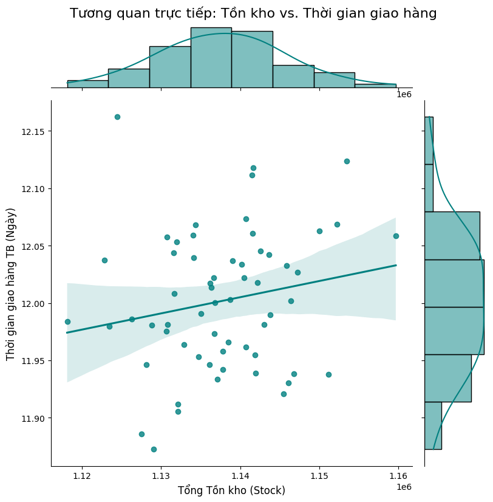

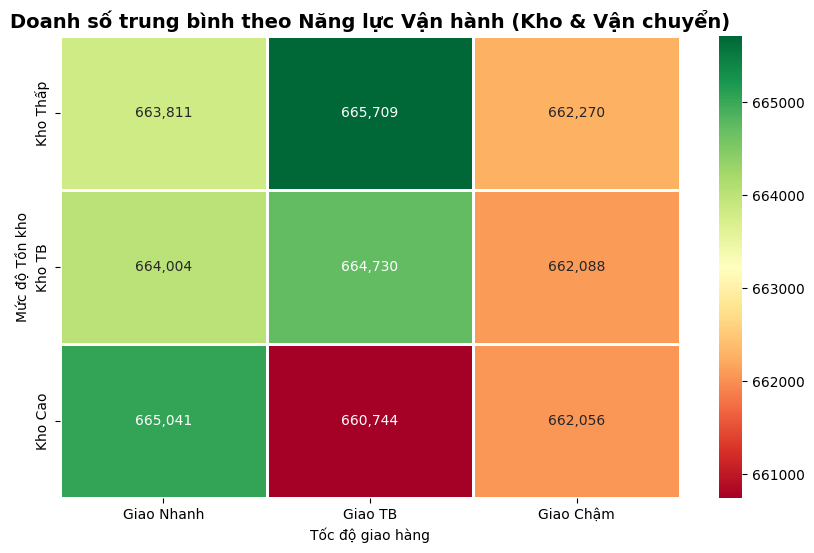

```python
plt.figure(figsize=(10, 8))
g = sns.jointplot(
    data=df_agg,
    x='stock_available',
    y='lead_time_days',
    kind='reg',             # Vẽ đường hồi quy
    color='teal',
    height=8
)
g.fig.suptitle('Tương quan trực tiếp: Tồn kho vs. Thời gian giao hàng', y=1.02, fontsize=16)
g.set_axis_labels('Tổng Tồn kho (Stock)', 'Thời gian giao hàng TB (Ngày)', fontsize=12)
plt.show()

df_agg['Stock_Level'] = pd.qcut(df_agg['stock_available'], q=3, labels=['Kho Thấp', 'Kho TB', 'Kho Cao'])

# Chia Lead Time thành 3 mức: Nhanh - Bình thường - Chậm
# Lưu ý: Lead tim e biến động ít nên dùng cut hoặc qcut tùy dữ liệu
try:
    df_agg['Delivery_Speed'] = pd.qcut(df_agg['lead_time_days'], q=3, labels=['Giao Nhanh', 'Giao TB', 'Giao Chậm'])
except:
    df_agg['Delivery_Speed'] = pd.cut(df_agg['lead_time_days'], bins=3, labels=['Nhanh', 'Trung bình', 'Chậm'])
# Tạo bảng Pivot
pivot_ops = df_agg.pivot_table(
    index='Stock_Level',
    columns='Delivery_Speed',
    values='units_sold',
    aggfunc='mean'
)
# Vẽ Heatmap
plt.figure(figsize=(10, 6))
sns.heatmap(pivot_ops, annot=True, fmt=',.0f', cmap='RdYlGn', linewidths=1)
plt.title('Doanh số trung bình theo Năng lực Vận hành (Kho & Vận chuyển)', fontsize=14, fontweight='bold')
plt.xlabel('Tốc độ giao hàng')
plt.ylabel('Mức độ Tồn kho')
plt.show()
```

• Nhận xét

Phân tích dữ liệu cho thấy việc tăng lượng tồn kho không giúp cải thiện tốc độ giao hàng, trái lại còn có xu hướng làm tăng nhẹ thời gian xử lý đơn hàng (tương quan dương), gợi ý các vấn đề về hiệu suất quản lý kho khi quá tải.

Về mặt hiệu quả kinh doanh, doanh số đạt đỉnh tại mức Tồn kho Thấp, cho thấy mô hình vận hành hiện tại phù hợp với chiến lược 'Tinh gọn' (Lean) hơn là chiến lược 'Dự trữ' (Stockpiling). Việc duy trì tồn kho cao nhưng tốc độ giao hàng không cải thiện (Giao TB) dẫn đến kết quả doanh số thấp nhất (Vùng rủi ro).

Khuyến nghị: Cần ưu tiên giảm mức tồn kho an toàn để giải phóng dòng tiền, đồng thời tập trung cải thiện quy trình xử lý đơn hàng để rút ngắn Lead time, thay vì cố gắng nhập thêm hàng để trữ.

5. So sánh hiệu suất giữa các mô hình học máy: Đâu là phương pháp tối ưu để dự báo tổng doanh số?

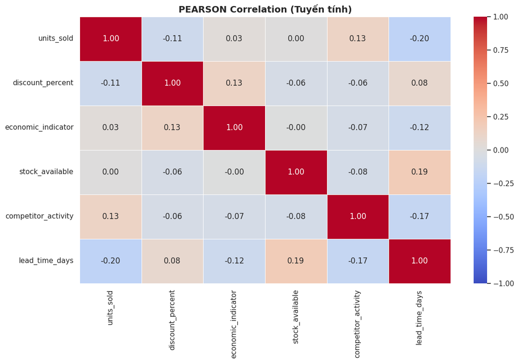

```python
cols_to_analyze = [
    'units_sold',
    'discount_percent',
    'economic_indicator',
    'stock_available',
    'competitor_activity',
    'lead_time_days',
]

# Lọc lấy đúng các cột cần thiết
df_plot = df_agg[cols_to_analyze]

corr_pearson = df_plot.corr(method='pearson')

# Vẽ biểu đồ
plt.subplots(figsize=(12, 8))
sns.heatmap(corr_pearson, annot=True, fmt=".2f", cmap='coolwarm',
            vmin=-1, vmax=1, linewidths=0.5)
plt.title('PEARSON Correlation (Tuyến tính)', fontsize=14, fontweight='bold')
plt.tight_layout()
plt.show()
```

Kết quả phân tích tương quan cho thấy toàn bộ các biến đầu vào đều có hệ số thấp. Điều này hàm ý rằng mối quan hệ giữa các biến giải thích và số lượng bán ra không phải dạng tuyến tính trực tiếp. Do đó, các mô hình tuyến tính như **Linear Regression** hoặc những mô hình giả định cấu trúc tuyến tính mạnh như **ARIMA/SARIMAX** sẽ không phù hợp, bởi chúng dựa vào giả định rằng khi biến X tăng/giảm thì biến Y sẽ thay đổi tương ứng theo một quy luật tuyến tính ổn định.

Tuy nhiên, dữ liệu thực tế thường chứa **các dạng quan hệ phi tuyến và tương tác giữa nhiều biến**. Ví dụ: giảm giá có thể chỉ tác động mạnh khi kết hợp đồng thời với thời gian giao hàng ngắn; hoặc tác động của thị trường chỉ thể hiện rõ khi mức độ hoạt động của đối thủ ở mức thấp. Đây là những dạng quan hệ mà heatmap không thể thể hiện, nhưng lại rất phổ biến trong dữ liệu kinh doanh.

Vì vậy, các mô hình có khả năng học được cấu trúc phi tuyến, ngưỡng (threshold) và tương tác phức tạp giữa các biến — chẳng hạn như** Random Forest và XGBoost** — là lựa chọn phù hợp hơn. Những mô hình này không phụ thuộc vào tương quan tuyến tính mà khai thác được sự kết hợp giữa các yếu tố, phản ánh chính xác hơn cơ chế hình thành doanh số trong thực tế.

### XGBOOST

4. TẠO BIẾN ĐẶC TRƯNG (FEATURE ENGINEERING)

```python
df_ml = df_agg.copy()

# A. Tạo Lags cho biến mục tiêu (Target Lags)
# Ý nghĩa: Doanh số của 1, 2, 3 tháng trước ảnh hưởng đến tháng này
df_ml['lag_1'] = df_ml['units_sold'].shift(1)
df_ml['lag_2'] = df_ml['units_sold'].shift(2)
df_ml['lag_3'] = df_ml['units_sold'].shift(3)
df_ml['lag_12'] = df_ml['units_sold'].shift(12) # So với cùng kỳ năm ngoái

# B. Tạo Rolling Mean (Trung bình trượt)
# Ý nghĩa: Xu hướng trung bình 3 tháng gần nhất
df_ml['rolling_mean_3'] = df_ml['units_sold'].shift(1).rolling(window=3).mean()

# C. Lấy sai phân (Diff) - Để bắt sự thay đổi thay vì số tuyệt đối
df_ml['diff_1'] = df_ml['units_sold'].diff(1)

# D. Thêm thông tin thời gian
df_ml['month'] = df_ml.index.month
df_ml['quarter'] = df_ml.index.quarter

# Loại bỏ các dòng bị NaN do quá trình shift (tạo lag)
df_ml = df_ml.dropna()

print(f"Dữ liệu sau khi tạo features: {df_ml.shape}")
print("=== DANH SÁCH CÁC ĐẶC TRƯNG (FEATURES) ===")
cols = df_ml.columns.tolist()
for i in range(0, len(cols), 3):
    print(", ".join(cols[i:i+3]))
```

```
Dữ liệu sau khi tạo features: (48, 14)
=== DANH SÁCH CÁC ĐẶC TRƯNG (FEATURES) ===
units_sold, stock_available, discount_percent
economic_indicator, competitor_activity, lead_time_days
lag_1, lag_2, lag_3
lag_12, rolling_mean_3, diff_1
month, quarter
```

5. CHIA TRAIN / TEST

```python
# Tách biến X và y
target = 'units_sold'
features = [col for col in df_ml.columns if col not in [target]]

X = df_ml[features]
y = df_ml[target]

# Chia theo thời gian (Không được shuffle)
test_size = 12
X_train, X_test = X.iloc[:-test_size], X.iloc[-test_size:]
y_train, y_test = y.iloc[:-test_size], y.iloc[-test_size:]
# === PHẦN THÔNG BÁO ===
print("-" * 30)
print("KẾT QUẢ CHIA TẬP DỮ LIỆU (TRAIN/TEST SPLIT)")
print("-" * 30)

# 1. Thông tin tập Train
print(f"1. Tập Huấn luyện (Train set):")
print(f"   - Kích thước: {X_train.shape}")
# Dùng .date() để chỉ lấy ngày tháng năm, bỏ giờ phút cho gọn
print(f"   - Thời gian:  Từ [{X_train.index.min().date()}] đến [{X_train.index.max().date()}]")

print("\n") # Xuống dòng cho thoáng

# 2. Thông tin tập Test
print(f"2. Tập Kiểm tra (Test set):")
print(f"   - Kích thước: {X_test.shape}")
print(f"   - Thời gian:  Từ [{X_test.index.min().date()}] đến [{X_test.index.max().date()}]")

print("-" * 30)
print(f"Tỷ lệ Test size: {len(X_test) / len(X) * 100:.1f}% trên tổng dữ liệu")
```

```
------------------------------
KẾT QUẢ CHIA TẬP DỮ LIỆU (TRAIN/TEST SPLIT)
------------------------------
1. Tập Huấn luyện (Train set):
   - Kích thước: (36, 13)
   - Thời gian:  Từ [2021-01-01] đến [2023-12-01]


2. Tập Kiểm tra (Test set):
   - Kích thước: (12, 13)
   - Thời gian:  Từ [2024-01-01] đến [2024-12-01]
------------------------------
Tỷ lệ Test size: 25.0% trên tổng dữ liệu
```

6. HUẤN LUYỆN XGBOOST

```python
# n_estimators: Số lượng cây
# learning_rate: Tốc độ học (thấp thì chậm nhưng chắc)
# max_depth: Độ sâu của cây (tránh overfitting)
params_manual = {
    'n_estimators': 1000,      # Giảm về 1000 (đủ dùng)
    'learning_rate': 0.05,     # Giữ nguyên
    'max_depth': 3,            # Giảm về 5 (Tránh học quá sâu vào chi tiết nhiễu)
    'random_state': 42,
    'n_jobs': -1,
    'early_stopping_rounds': 50
}
model = XGBRegressor(**params_manual)

model.fit(X_train, y_train,
          eval_set=[(X_train, y_train), (X_test, y_test)],
          verbose=False)
```

```
XGBRegressor(base_score=None, booster=None, callbacks=None,
             colsample_bylevel=None, colsample_bynode=None,
             colsample_bytree=None, device=None, early_stopping_rounds=50,
             enable_categorical=False, eval_metric=None, feature_types=None,
             feature_weights=None, gamma=None, grow_policy=None,
             importance_type=None, interaction_constraints=None,
             learning_rate=0.05, max_bin=None, max_cat_threshold=None,
             max_cat_to_onehot=None, max_delta_step=None, max_depth=3,
             max_leaves=None, min_child_weight=None, missing=nan,
             monotone_constraints=None, multi_strategy=None, n_estimators=1000,
             n_jobs=-1, num_parallel_tree=None, ...)
```

7. DỰ BÁO VÀ ĐÁNH GIÁ

```
🏆 KẾT QUẢ XGBOOST:
RMSE: 3,676.71
MAPE: 0.46%
R2 Score: 0.4214
```

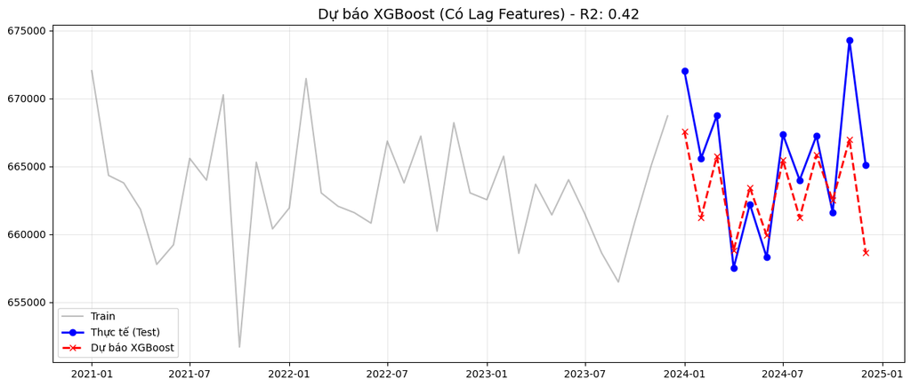

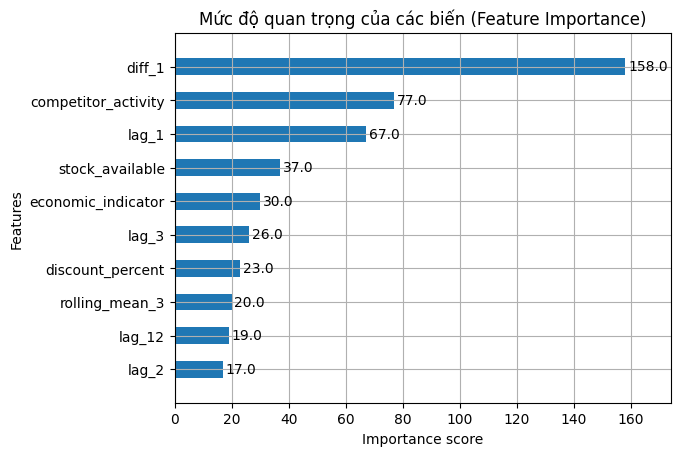

```python
preds = model.predict(X_test)

# Tính chỉ số
rmse = np.sqrt(mean_squared_error(y_test, preds))
mape = mean_absolute_percentage_error(y_test, preds)
r2 = r2_score(y_test, preds)

print(f"\n🏆 KẾT QUẢ XGBOOST:")
print(f"RMSE: {rmse:,.2f}")
print(f"MAPE: {mape:.2%}")
print(f"R2 Score: {r2:.4f}")

# Vẽ biểu đồ
plt.figure(figsize=(15, 6))
plt.plot(y_train.index, y_train, label='Train', color='gray', alpha=0.5)
plt.plot(y_test.index, y_test, label='Thực tế (Test)', color='blue', linewidth=2, marker='o')
plt.plot(y_test.index, preds, label='Dự báo XGBoost', color='red', linestyle='--', linewidth=2, marker='x')

plt.title(f'Dự báo XGBoost (Có Lag Features) - R2: {r2:.2f}', fontsize=14)
plt.legend()
plt.grid(True, alpha=0.3)
plt.show()

# Xem biến nào quan trọng nhất
plt.figure(figsize=(10, 5))
plot_importance(model, max_num_features=10, height=0.5)
plt.title("Mức độ quan trọng của các biến (Feature Importance)")
plt.show()
```

Mô hình có độ chính xác rất cao về mặt giá trị (MAPE và RMSE tốt), phù hợp để hoạch định nguồn lực, nhưng lại khá "thận trọng" trước các biến động lớn (R2 0.42). Dù đã tận dụng tốt dữ liệu lịch sử (diff_1) và yếu tố cạnh tranh (compectior_activity), mô hình vẫn chưa bắt được nhịp các điểm đỉnh/đáy đột biến của thị trường.

### RANDOM FOREST REGRESSOR

4. TẠO BIẾN ĐẶC TRƯNG (FEATURE ENGINEERING)

```python
df_ml = df_agg.copy()

# A. Tạo Lags cho biến mục tiêu (Target Lags)
# Ý nghĩa: Doanh số của 1, 2, 3 tháng trước ảnh hưởng đến tháng này
df_ml['lag_1'] = df_ml['units_sold'].shift(1)
df_ml['lag_2'] = df_ml['units_sold'].shift(2)
df_ml['lag_3'] = df_ml['units_sold'].shift(3)
df_ml['lag_12'] = df_ml['units_sold'].shift(12) # So với cùng kỳ năm ngoái

# B. Tạo Rolling Mean (Trung bình trượt)
# Ý nghĩa: Xu hướng trung bình 3 tháng gần nhất
df_ml['rolling_mean_3'] = df_ml['units_sold'].shift(1).rolling(window=3).mean()

# C. Lấy sai phân (Diff) - Để bắt sự thay đổi thay vì số tuyệt đối
df_ml['diff_1'] = df_ml['units_sold'].diff(1)

# D. Thêm thông tin thời gian
df_ml['month'] = df_ml.index.month
df_ml['quarter'] = df_ml.index.quarter

# Loại bỏ các dòng bị NaN do quá trình shift (tạo lag)
df_ml = df_ml.dropna()

print(f"Dữ liệu sau khi tạo features: {df_ml.shape}")
print("=== DANH SÁCH CÁC ĐẶC TRƯNG (FEATURES) ===")
cols = df_ml.columns.tolist()
for i in range(0, len(cols), 3):
    print(", ".join(cols[i:i+3]))
```

```
Dữ liệu sau khi tạo features: (48, 14)
=== DANH SÁCH CÁC ĐẶC TRƯNG (FEATURES) ===
units_sold, stock_available, discount_percent
economic_indicator, competitor_activity, lead_time_days
lag_1, lag_2, lag_3
lag_12, rolling_mean_3, diff_1
month, quarter
```

5. CHIA TRAIN / TEST

```python
# Tách biến X và y
target = 'units_sold'
features = [col for col in df_ml.columns if col not in [target]]

X = df_ml[features]
y = df_ml[target]

# Chia theo thời gian (Không được shuffle)
test_size = 12
X_train, X_test = X.iloc[:-test_size], X.iloc[-test_size:]
y_train, y_test = y.iloc[:-test_size], y.iloc[-test_size:]
# === PHẦN THÔNG BÁO ===
print("-" * 30)
print("KẾT QUẢ CHIA TẬP DỮ LIỆU (TRAIN/TEST SPLIT)")
print("-" * 30)

# 1. Thông tin tập Train
print(f"1. Tập Huấn luyện (Train set):")
print(f"   - Kích thước: {X_train.shape}")
# Dùng .date() để chỉ lấy ngày tháng năm, bỏ giờ phút cho gọn
print(f"   - Thời gian:  Từ [{X_train.index.min().date()}] đến [{X_train.index.max().date()}]")

print("\n") # Xuống dòng cho thoáng

# 2. Thông tin tập Test
print(f"2. Tập Kiểm tra (Test set):")
print(f"   - Kích thước: {X_test.shape}")
print(f"   - Thời gian:  Từ [{X_test.index.min().date()}] đến [{X_test.index.max().date()}]")

print("-" * 30)
print(f"Tỷ lệ Test size: {len(X_test) / len(X) * 100:.1f}% trên tổng dữ liệu")
```

```
------------------------------
KẾT QUẢ CHIA TẬP DỮ LIỆU (TRAIN/TEST SPLIT)
------------------------------
1. Tập Huấn luyện (Train set):
   - Kích thước: (36, 13)
   - Thời gian:  Từ [2021-01-01] đến [2023-12-01]


2. Tập Kiểm tra (Test set):
   - Kích thước: (12, 13)
   - Thời gian:  Từ [2024-01-01] đến [2024-12-01]
------------------------------
Tỷ lệ Test size: 25.0% trên tổng dữ liệu
```

6. HUẤN LUYỆN RANDOMFOREST

```python
print("🌲 Đang chạy Grid Search cho Random Forest (Vui lòng đợi)...")

# Định nghĩa lưới tham số cần thử
param_grid = {
    'n_estimators': [300,500],
    'max_depth': [3,5],
    'min_samples_leaf': [2,3,4],
    'max_features': [None]
}

# Thiết lập Cross-Validation cho chuỗi thời gian
tscv = TimeSeriesSplit(n_splits=3)
rf_base = RandomForestRegressor(random_state=42, n_jobs=-1)

# Chạy tìm kiếm
grid_search = GridSearchCV(estimator=rf_base,
                           param_grid=param_grid,
                           cv=tscv,
                           scoring='neg_mean_squared_error',
                           verbose=1)
grid_search.fit(X_train, y_train)

# Lấy mô hình tốt nhất
best_params = grid_search.best_params_
print(f"✅ Tham số tốt nhất: {best_params}")

model = RandomForestRegressor(**best_params, random_state=42, n_jobs=-1)
model.fit(X_train, y_train)
```

```
🌲 Đang chạy Grid Search cho Random Forest (Vui lòng đợi)...
Fitting 3 folds for each of 12 candidates, totalling 36 fits
✅ Tham số tốt nhất: {'max_depth': 5, 'max_features': None, 'min_samples_leaf': 3, 'n_estimators': 500}
```

```
RandomForestRegressor(max_depth=5, max_features=None, min_samples_leaf=3,
                      n_estimators=500, n_jobs=-1, random_state=42)
```

7. DỰ BÁO VÀ ĐÁNH GIÁ

```
🏆 KẾT QUẢ RANDOM FOREST:
RMSE: 3,644.73
MAPE: 0.46%
R2 Score: 0.4314
```

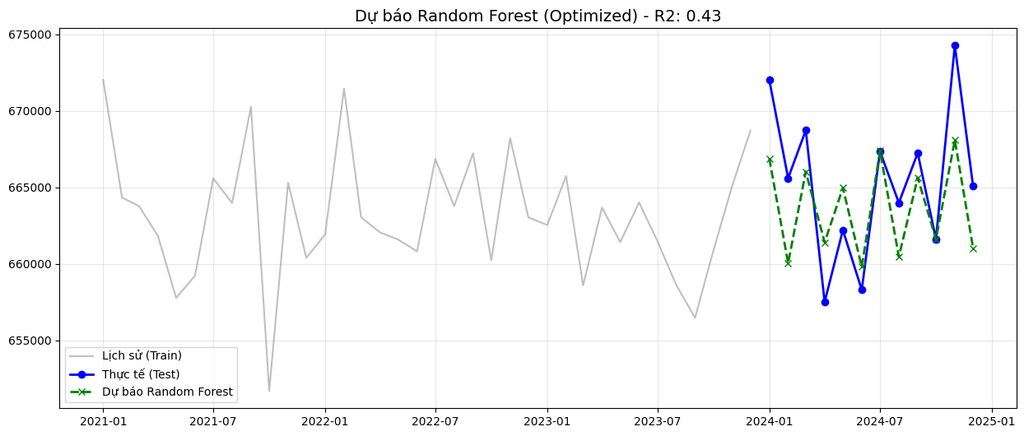

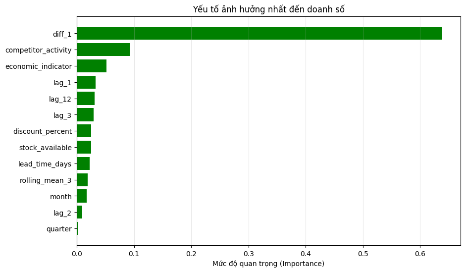

```python
preds = model.predict(X_test)

# Chỉ số
rmse = np.sqrt(mean_squared_error(y_test, preds))
mape = mean_absolute_percentage_error(y_test, preds)
r2 = r2_score(y_test, preds)

print(f"\n🏆 KẾT QUẢ RANDOM FOREST:")
print(f"RMSE: {rmse:,.2f}")
print(f"MAPE: {mape:.2%}")
print(f"R2 Score: {r2:.4f}")

# Vẽ biểu đồ Line Chart
plt.figure(figsize=(15, 6))
plt.plot(y_train.index, y_train, label='Lịch sử (Train)', color='gray', alpha=0.5)
plt.plot(y_test.index, y_test, label='Thực tế (Test)', color='blue', linewidth=2, marker='o')
plt.plot(y_test.index, preds, label='Dự báo Random Forest', color='green', linestyle='--', linewidth=2, marker='x')

plt.title(f'Dự báo Random Forest (Optimized) - R2: {r2:.2f}', fontsize=14)
plt.legend()
plt.grid(True, alpha=0.3)
plt.show()

# Vẽ biểu đồ Feature Importance
sorted_idx = model.feature_importances_.argsort()
plt.figure(figsize=(10, 6))
plt.barh(X.columns[sorted_idx], model.feature_importances_[sorted_idx], color='green')
plt.xlabel("Mức độ quan trọng (Importance)")
plt.title("Yếu tố ảnh hưởng nhất đến doanh số")
plt.grid(axis='x', alpha=0.3)
plt.show()
```

### VOTING REGRESSOR (XGBOOST + RANDOM FOREST + LINEAR)

4. TẠO BIẾN ĐẶC TRƯNG (FEATURE ENGINEERING)

```python
df_ml = df_agg.copy()

# A. Tạo Lags cho biến mục tiêu (Target Lags)
# Ý nghĩa: Doanh số của 1, 2, 3 tháng trước ảnh hưởng đến tháng này
df_ml['lag_1'] = df_ml['units_sold'].shift(1)
df_ml['lag_2'] = df_ml['units_sold'].shift(2)
df_ml['lag_3'] = df_ml['units_sold'].shift(3)
df_ml['lag_12'] = df_ml['units_sold'].shift(12) # So với cùng kỳ năm ngoái

# B. Tạo Rolling Mean (Trung bình trượt)
# Ý nghĩa: Xu hướng trung bình 3 tháng gần nhất
df_ml['rolling_mean_3'] = df_ml['units_sold'].shift(1).rolling(window=3).mean()

# C. Lấy sai phân (Diff) - Để bắt sự thay đổi thay vì số tuyệt đối
df_ml['diff_1'] = df_ml['units_sold'].diff(1)

# D. Thêm thông tin thời gian
df_ml['month'] = df_ml.index.month
df_ml['quarter'] = df_ml.index.quarter

# Loại bỏ các dòng bị NaN do quá trình shift (tạo lag)
df_ml = df_ml.dropna()

print(f"Dữ liệu sau khi tạo features: {df_ml.shape}")
print("=== DANH SÁCH CÁC ĐẶC TRƯNG (FEATURES) ===")
cols = df_ml.columns.tolist()
for i in range(0, len(cols), 3):
    print(", ".join(cols[i:i+3]))
```

```
Dữ liệu sau khi tạo features: (48, 14)
=== DANH SÁCH CÁC ĐẶC TRƯNG (FEATURES) ===
units_sold, stock_available, discount_percent
economic_indicator, competitor_activity, lead_time_days
lag_1, lag_2, lag_3
lag_12, rolling_mean_3, diff_1
month, quarter
```

5. CHIA TRAIN / TEST

```python
# Tách biến X và y
target = 'units_sold'
features = [col for col in df_ml.columns if col not in [target]]

X = df_ml[features]
y = df_ml[target]

# Chia theo thời gian (Không được shuffle)
test_size = 12
X_train, X_test = X.iloc[:-test_size], X.iloc[-test_size:]
y_train, y_test = y.iloc[:-test_size], y.iloc[-test_size:]
# === PHẦN THÔNG BÁO ===
print("-" * 30)
print("KẾT QUẢ CHIA TẬP DỮ LIỆU (TRAIN/TEST SPLIT)")
print("-" * 30)

# 1. Thông tin tập Train
print(f"1. Tập Huấn luyện (Train set):")
print(f"   - Kích thước: {X_train.shape}")
# Dùng .date() để chỉ lấy ngày tháng năm, bỏ giờ phút cho gọn
print(f"   - Thời gian:  Từ [{X_train.index.min().date()}] đến [{X_train.index.max().date()}]")

print("\n") # Xuống dòng cho thoáng

# 2. Thông tin tập Test
print(f"2. Tập Kiểm tra (Test set):")
print(f"   - Kích thước: {X_test.shape}")
print(f"   - Thời gian:  Từ [{X_test.index.min().date()}] đến [{X_test.index.max().date()}]")

print("-" * 30)
print(f"Tỷ lệ Test size: {len(X_test) / len(X) * 100:.1f}% trên tổng dữ liệu")
```

```
------------------------------
KẾT QUẢ CHIA TẬP DỮ LIỆU (TRAIN/TEST SPLIT)
------------------------------
1. Tập Huấn luyện (Train set):
   - Kích thước: (36, 13)
   - Thời gian:  Từ [2021-01-01] đến [2023-12-01]


2. Tập Kiểm tra (Test set):
   - Kích thước: (12, 13)
   - Thời gian:  Từ [2024-01-01] đến [2024-12-01]
------------------------------
Tỷ lệ Test size: 25.0% trên tổng dữ liệu
```

6. KHỞI TẠO 3 MÔ HÌNH THÀNH PHẦN

```python
print("⚔️ Đang khởi tạo và huấn luyện 3 Mô hình...")

# 1. XGBoost (Cấu hình mạnh mẽ để bắt đỉnh)
# Lưu ý: Trong Voting, ta bỏ early_stopping để tránh lỗi cú pháp, thay vào đó dùng n_estimators vừa đủ
xgb_model = XGBRegressor(
    n_estimators=1000,
    learning_rate=0.01,
    max_depth=6,         # Sâu để bắt nhiễu tốt
    subsample=0.8,
    colsample_bytree=0.8,
    random_state=42,
    n_jobs=-1
)

# 2. Random Forest (Cấu hình an toàn để ổn định hóa)
rf_model = RandomForestRegressor(
    n_estimators=1000,
    max_depth=10,        # Không quá sâu để tránh overfitting
    min_samples_leaf=2,
    random_state=42,
    n_jobs=-1
)

# 3. Linear Regression (Để giữ đường xu hướng thẳng)
lr_model = LinearRegression()

# === THÔNG BÁO HOÀN TẤT ===
print("\n" + "="*45)
print("✅ KHỞI TẠO THÀNH CÔNG 3 MÔ HÌNH (READY)")
print("="*45)
print(f"1. XGBoost       | Trees: {xgb_model.n_estimators}, LR: {xgb_model.learning_rate}, Depth: {xgb_model.max_depth}")
print(f"2. Random Forest | Trees: {rf_model.n_estimators}, Depth: {rf_model.max_depth}")
print(f"3. Linear Reg    | (Base Trend)")
print("-" * 45)
```

```
⚔️ Đang khởi tạo và huấn luyện 3 Mô hình...

=============================================
✅ KHỞI TẠO THÀNH CÔNG 3 MÔ HÌNH (READY)
=============================================
1. XGBoost       | Trees: 1000, LR: 0.01, Depth: 6
2. Random Forest | Trees: 1000, Depth: 10
3. Linear Reg    | (Base Trend)
---------------------------------------------
```

7. HUẤN LUYỆN VOTING REGRESSOR

```python
# Kết hợp 3 model lại
voting_model = VotingRegressor(estimators=[
    ('xgb', xgb_model),
    ('rf', rf_model),
    ('lr', lr_model)
])
# Huấn luyện mô hình tổng
voting_model.fit(X_train, y_train)
print("✅ Huấn luyện xong Voting Model!")
```

```
✅ Huấn luyện xong Voting Model!
```

8. DỰ BÁO VÀ ĐÁNH GIÁ

```
----------------------------------------
🏆 KẾT QUẢ FINAL (XGB + RF + LINEAR):
RMSE: 2,514.32
MAPE: 0.31%
R2 Score: 0.7294
----------------------------------------
```

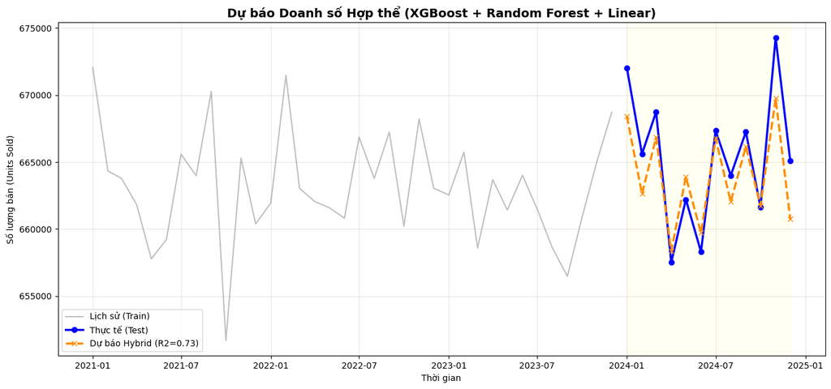

```python
preds = voting_model.predict(X_test)

# Tính toán các chỉ số
rmse = np.sqrt(mean_squared_error(y_test, preds))
mape = mean_absolute_percentage_error(y_test, preds)
r2 = r2_score(y_test, preds)

print("-" * 40)
print(f"🏆 KẾT QUẢ FINAL (XGB + RF + LINEAR):")
print(f"RMSE: {rmse:,.2f}")
print(f"MAPE: {mape:.2%}")
print(f"R2 Score: {r2:.4f}")
print("-" * 40)

plt.figure(figsize=(16, 7))

# 1. Vẽ Lịch sử (Train)
plt.plot(y_train.index, y_train, label='Lịch sử (Train)', color='gray', alpha=0.5)

# 2. Vẽ Thực tế (Test)
plt.plot(y_test.index, y_test, label='Thực tế (Test)', color='blue', linewidth=2.5, marker='o')

# 3. Vẽ Dự báo (Hybrid)
plt.plot(y_test.index, preds, label=f'Dự báo Hybrid (R2={r2:.2f})', color='darkorange', linestyle='--', linewidth=2.5, marker='x')

# Trang trí biểu đồ
plt.title(f'Dự báo Doanh số Hợp thể (XGBoost + Random Forest + Linear)', fontsize=14, fontweight='bold')
plt.xlabel('Thời gian')
plt.ylabel('Số lượng bán (Units Sold)')
plt.legend()
plt.grid(True, alpha=0.3)

# Đánh dấu vùng dự báo
plt.axvspan(y_test.index[0], y_test.index[-1], color='yellow', alpha=0.05)

plt.show()
```